# Лабораторная работа №3

Имитационное моделирование: Агентный подход (Daisyworld)

Виктория Симонова

nikolkidm40@gmail.com

Российский университет дружбы народов

2026-03-21

# Информация

## Докладчик

- Симонова Виктория Игоревна
- студент
- Российский университет дружбы народов им. П. Лумумбы
- nikolkidm40@gmail.com
- https://github.com/ViISimonova

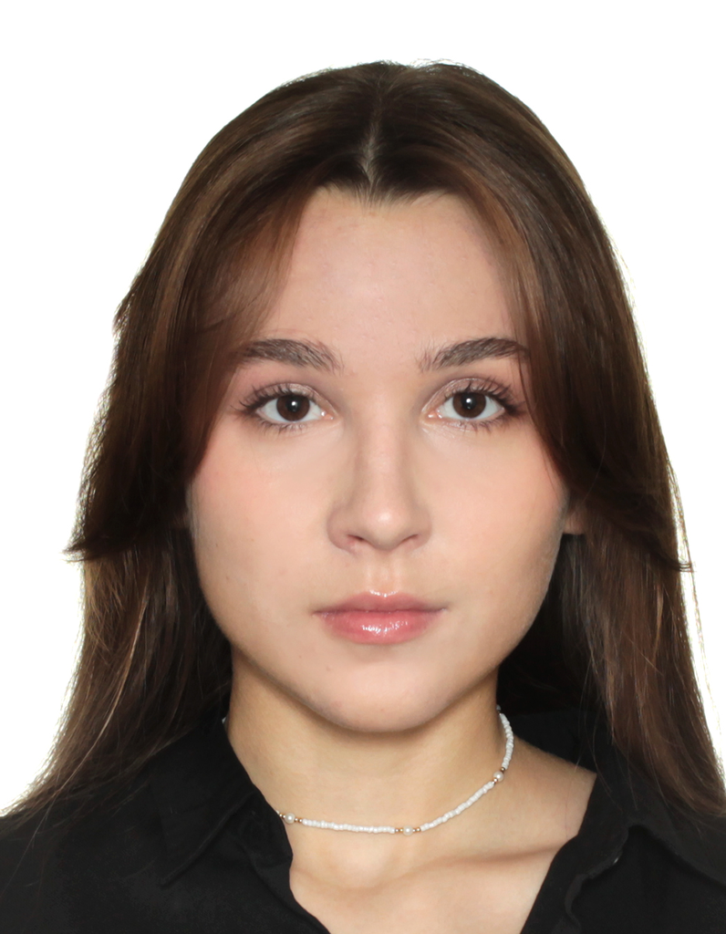

# Вводная часть

## Актуальность

- Изучение механизмов саморегуляции планет (гипотеза Гайи)
- Применение агентного подхода (ABM) для сложных систем
- Использование пакета `Agents.jl` в экосистеме Julia
- Автоматизация научных исследований с помощью `DrWatson`

## Объект и предмет исследования

- Модель “Маргариткового мира” (Daisyworld)
- Взаимодействие биологических видов с климатом
- Программный инструментарий: Julia, Agents.jl, CairoMakie

## Цели и задачи

- Реализовать агентную модель Daisyworld
- Исследовать влияние светимости Солнца на температуру планеты
- Провести многофакторный анализ параметров (`max_age`, `init_white`)
- Сгенерировать комплексную отчетность в разных форматах

# Ход работы

## Подготовка окружения

Настройка проекта с помощью `DrWatson` и установка зависимостей.

[figure not shown]

## Базовая визуализация

Отображение маргариток на сетке и тепловой карты температуры.

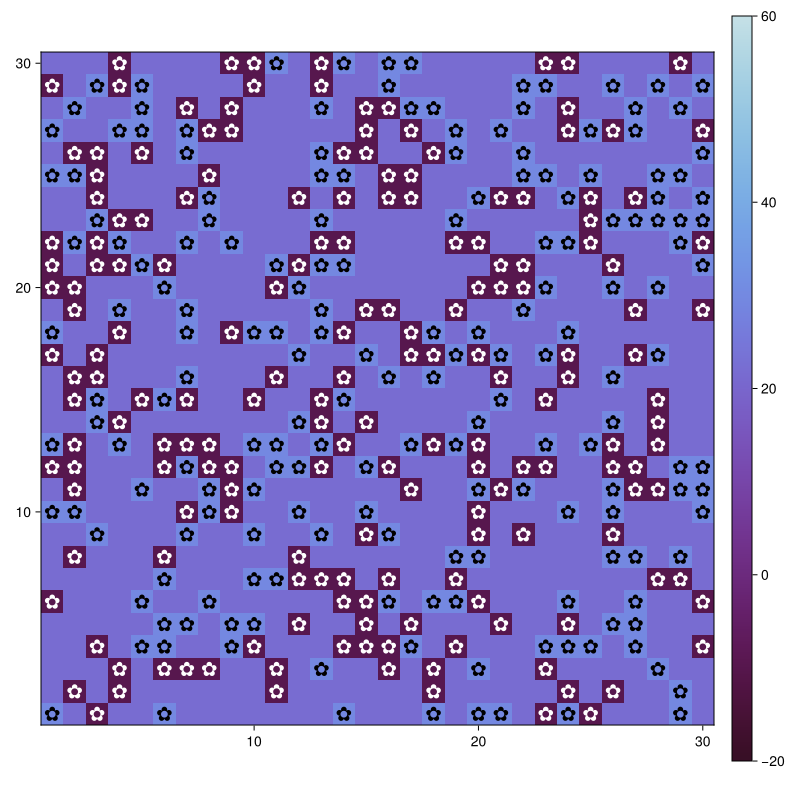

## Эволюция системы

Наблюдение за динамикой на шагах 5 и 40. Стабилизация климата.

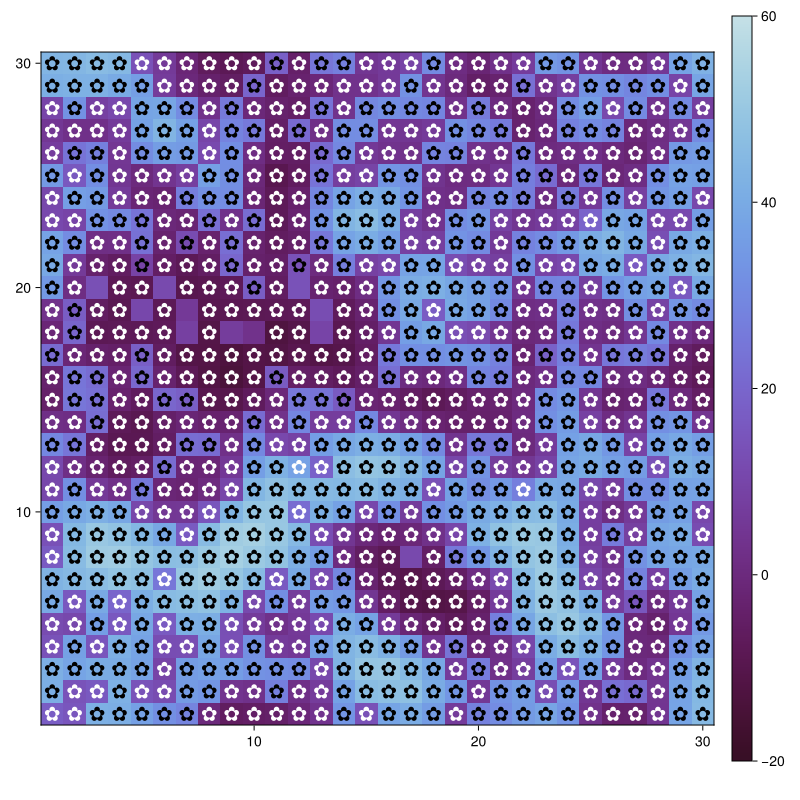

## Анимация модели

Создание видеопотока для визуализации процесса саморегуляции.

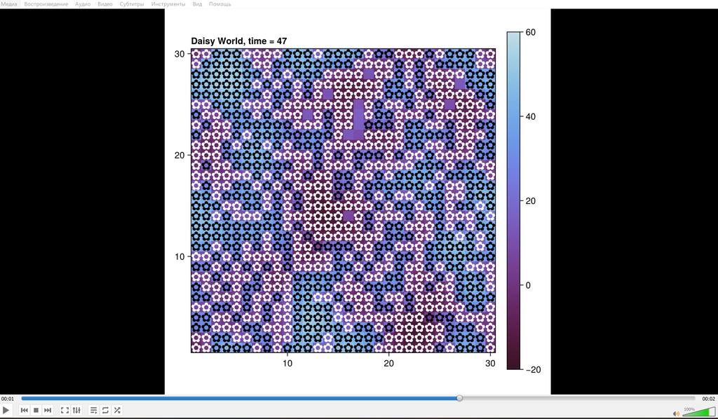

## Динамика популяций

Сбор данных о численности черных и белых маргариток.

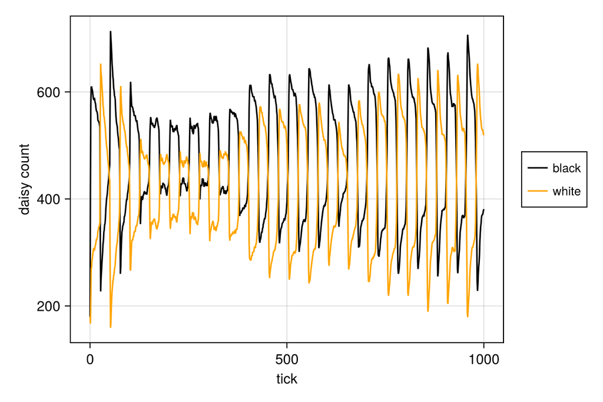

## Сценарий со светимостью

Анализ выживаемости при постепенном росте солнечной активности (`:ramp`).

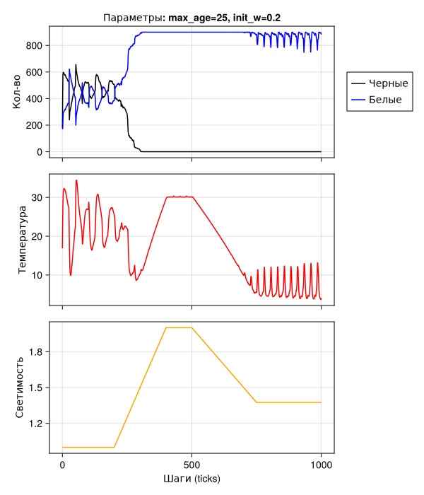

## Параметрические исследования

Использование `dict_list` для генерации серийных экспериментов.

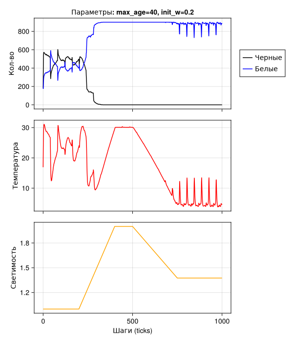

## Производные форматы

Автоматическая генерация `.jl`, `.ipynb` и `.qmd` файлов.

[figure not shown]

# Результаты моделирования

## Сравнение сценариев

Влияние параметров на устойчивость системы.

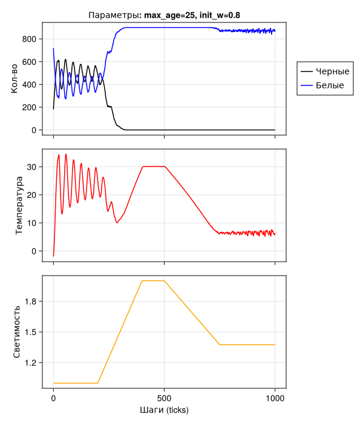

# Заключение

## Выводы

- Освоены навыки построения агентных моделей в Julia.
- Подтверждена способность системы Daisyworld к терморегуляции.
- Изучены инструменты автоматизации серийных расчетов `DrWatson`.
- Реализован полный цикл “литературного программирования”.